# ECO 634 Lab 09 Modeling 2

Megan Mitchell

11/14/2021

# Lab Questions

## Q1

State the null hypothesis of the Chi-square test. Make sure you state the null hypothesis in terms of Brown Creeper presence/absence and edge/interior habitats.

```
The null hypothesis is that Brown creeper presence or absence is independent of edge or interior habitats.
In other words, there is no relationship between these variables.
```

## Q2

Consider the results of your test and explain whether you think that Brown Creepers show a significant habitat preference.Make sure your use the output of your statistical test to support your answer.

```
Based on the contingency table and Chi.Square test, Brown Creepers show a significant interior habitat preference relative to edge habitats (p-value < 0.05)

Contingency Table

 FALSE TRUE

  E   144   29

  I   559  314

Pearson's Chi-squared test with Yates' continuity correction

 data:  br_creeper_table
 X-squared = 23.3, df = 1, p-value = 1.386e-06
```

## Q3

Show the R-code you can use to create a model fit (call it fit_species) of penguin body mass as predicted by penguin species.

```
fit_species =
  lm(
    formula = body_mass_g ~ species,
    data = penguins)
```

## Q4

Show the R-code you can use to create a model fit (call it fit_sex) of penguin body mass as predicted by sex

```
fit_sex =
  lm(
  formula = body_mass_g ~ sex,
  data = penguins)
```

## Q5

Show the R-code you can use to create a model fit (call it fit_both) of penguin body mass as predicted by species and sex.

```
fit_both = lm(formula=body_mass_g ~ species * sex,
          data = penguins)
```

## Q6

Include a conditional boxplot corresponding to your fit_species model.

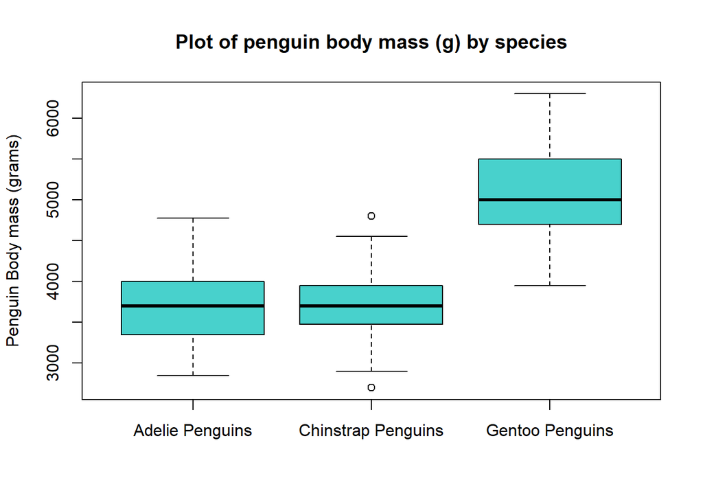

```r
boxplot(formula = body_mass_g ~ species,
        data = penguins,
        main = "Plot of penguin body mass (g) by species", xlab="",
        ylab = "Penguin Body mass (grams)", col = "mediumturquoise",
        names = c("Adelie Penguins", "Chinstrap Penguins", "Gentoo Penguins"))
```

## Q7

Include a conditional boxplot corresponding to your fit_sex model.

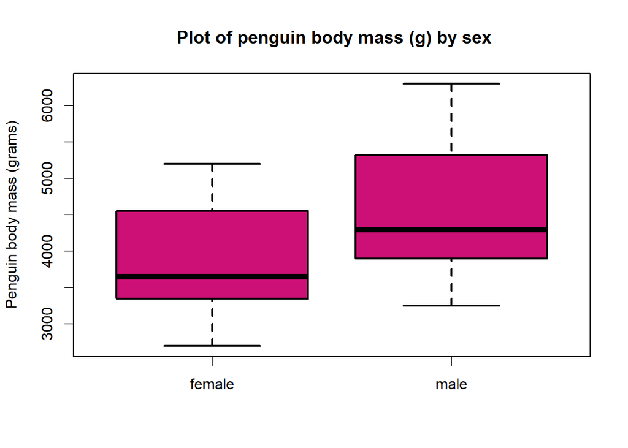

```r
boxplot(formula = body_mass_g ~ sex,
        data = penguins, lwd = 2, col = "deeppink3", font = 3,
        main = " Plot of penguin body mass (g) by sex",
        xlab = "", ylab = "Penguin body mass (grams)")
```

## Q8

Include a conditional boxplot corresponding to your fit_both model. Your group labels must all correspond to the correct box, be visible, and sensible.

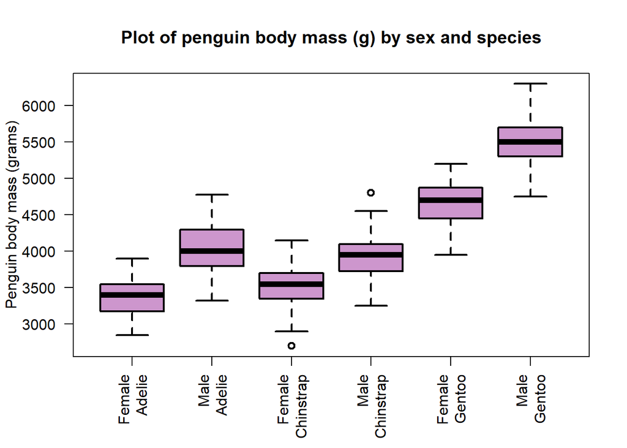

```r
require(palmerpenguins)
boxplot(formula = body_mass_g ~ sex:species,
        data = penguins, lwd = 2, col = "plum3", font = 3,
        main = "Plot of penguin body mass (g) by sex and species", las = 2,
        ylab= "Penguin body mass (grams)", xlab = " ",
        names = c("Female\nAdelie", "Male\nAdelie", "Female\nChinstrap", "Male\nChinstrap", "Female\nGentoo", "Male\nGentoo"))
```

## Q9

Based on the shapes of the boxes, which of the models (if any) do you think may have problems fulfilling the homogeneity assumption?

[output not shown]

## Q10

State the null hypothesis of the Bartlett test.

```
The null hypothesis of the Bartlett test is that there is no difference in variance between groups.
```

## Q11

What was the p-value from the Bartlett test of homogeneity for observations grouped by species? You can round your answer to 4 decimal digits.

```
The p-value was 0.0501.
bartlett.test(body_mass_g ~ species, data = penguins)
```

## Q12

What was the p-value from the Bartlett test of homogeneity for observations grouped by sex? You can round your answer to 4 decimal digits.

```
The p-value was 0.0320.
bartlett.test(body_mass_g ~ sex, data = penguins)
```

## Q13

What was the p-value from the Bartlett test of homogeneity for observations grouped by both factors? You can round your answer to 4 decimal digits

```
The p-value was 0.1741.
bartlett.test(dat_groups$body_mass_g)
```

## Q14

Based on the results of the Bartlett tests, do you anticipate any issues with heterogeneity in any of the models? Make sure you justify your response with the results of your tests.

[output not shown]